# R Notebook

```r
library(dplyr)
library(lavaan)
source("HINTS_preprocessing.R")
hints5 <-get_hints5()
```

```
[1] "hints5_cycle2_public.sav"
[1] TRUE
[1] "PR_RUCA_2010TRUE"
[1] "RUC2013TRUE"
[1] TRUE
[1] TRUE
[1] "hints5_cycle1_public.sav"
[1] TRUE
[1] "PR_RUCA_2010TRUE"
[1] "RUC2013TRUE"
[1] TRUE
[1] TRUE
[1] "hints5_cycle3_public.sav"
[1] TRUE
[1] "PR_RUCA_2010TRUE"
[1] "RUC2013TRUE"
[1] TRUE
[1] TRUE
[1] "hints5_cycle4_public.sav"
[1] TRUE
[1] "PR_RUCA_2010TRUE"
[1] "RUC2013TRUE"
[1] TRUE
[1] TRUE
```

```r
boot_times<-100

zscore <- function(x){
    return((x-mean(x,na.rm=TRUE))/sd(x,na.rm=TRUE))
}
```

```r
table(hints5$GeneralHealth_of) %>% cumsum / sum(!is.na(hints5$GeneralHealth_of))
```

```
Excellent Very good      Good      Fair      Poor
0.1164388 0.4774746 0.8349820 0.9737887 1.0000000
```

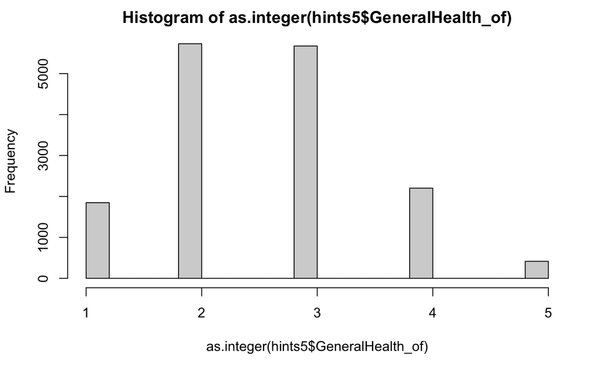

```r
hist(as.integer(hints5$GeneralHealth_of))
```

```r
library(magrittr)
library(dplyr)



data_dir <- "/Users/benjaminsmith/Dropbox (University of Oregon)/UO-SAN Lab/Berkman Lab/Devaluation/analysis_files/data/"

preprocessed_data_filepath <- paste0(data_dir,"cloudresearch_survey_results/orfcs_preprocessed2_anon_by_subj.csv")
library(readr)
library(ggplot2)
library(GGally)
orfcs_dataset <- readr::read_csv(preprocessed_data_filepath)
```

Let’s do our best to include all the same covariates we previously included.

# HINTS dataset: two mediators

This follows Hayes PROCESS Model 6 with two mediators but we are doing it here in Lavaan.

Variables are:

- Treatment: Rurality
- Two Mediators: household income, and fruit and vegetable consumption, in that order.
- Outcome: Physical and health measures. Altogether, we’ll repeat the mediation several times, with the following outcomes variables: BMI, self-rated health, aggregated cardiometabolic health, and high blood pressure. (and cancer??)

This model below is adapted from https://towardsdatascience.com/doing-and-reporting-a-serial-mediation-model-with-two-mediators-in-r-with-lavaan-739ed3155814

I think they’ve left some things out. I need to do a bit more research to work out how to properly implement this, probably including a basic crash course in SEM.

```r
library(stringi)
# [1] "Fruit_vegetables_z~HINTSIsRural_i+Age_c+I(Age_c^2)+RacePP+Gender3C+filename"
# [1] "MedConditions_HighBP_i~Fruit_vegetables_z+HINTSIsRural_i+Age_c+I(Age_c^2)+RacePP+Gender3C+filename"
# IncomeRanges_r

#need to do prepare variables so lavaan can process them
hints5_pp <- hints5
#add quadratic
hints5_pp$Age_c_pow2 <- hints5_pp$Age_c^2


#one-hot some variables
factor_to_clean_string <- function(data, col_to_stringify){
  data[[col_to_stringify]] <- as.character(data[[col_to_stringify]])
  data[[col_to_stringify]] <- (
    str_replace_all(data[[col_to_stringify]],"\\s","_") %>%
      str_replace_all("\\W","")
  )#table(hints5_pp[[col_to_stringify]])
  return(data)
}

hints5_pp<-factor_to_clean_string(hints5_pp,"RacePP2")
hints5_pp$RacePP2<-factor(hints5_pp$RacePP2)
hints5_pp <- mltools::one_hot(hints5_pp,"RacePP2",dropCols = FALSE)
print(paste0(colnames(hints5_pp)[grepl("RacePP2_",colnames(hints5_pp))],collapse=" + "))
```

```
[1] "RacePP2_American_Indian_or_Alaska_Native + RacePP2_Asian_Indian + RacePP2_Black + RacePP2_Chinese + RacePP2_Filipino + RacePP2_Japanese + RacePP2_Korean + RacePP2_Missing_Data + RacePP2_Multiple_races_selected + RacePP2_Other_Asian + RacePP2_Pacific_Islander + RacePP2_Vietnamese + RacePP2_White…
```

```r
hints5_pp<-factor_to_clean_string(hints5_pp,"Gender3C")
hints5_pp$Gender3C<-factor(hints5_pp$Gender3C)
hints5_pp <- mltools::one_hot(hints5_pp,"Gender3C",dropCols = FALSE)
print(paste0(colnames(hints5_pp)[grepl("Gender3C_",colnames(hints5_pp))],collapse=" + "))
```

```
[1] "Gender3C_Female + Gender3C_Male + Gender3C_MissingOrMultiple"
```

Now prepare the ORFCS dataset for lavaan.

```r
orfcs_dataset$BMI_z <- zscore(orfcs_dataset$BMI)
orfcs_dataset$DEMO_Age_z <- zscore(orfcs_dataset$DEMO_Age)

#need to do prepare variables so lavaan can process them
orfcs_dataset_pp <- data.table(orfcs_dataset)
#add quadratic
orfcs_dataset_pp$DEMO_Age_pow2_z <- zscore(orfcs_dataset_pp$DEMO_Age^2)


#one-hot some variables



orfcs_dataset_pp<-factor_to_clean_string(orfcs_dataset_pp,"RaceC2")
orfcs_dataset_pp$RaceC2<-factor(orfcs_dataset_pp$RaceC2)
orfcs_dataset_pp <- mltools::one_hot(orfcs_dataset_pp,"RaceC2",dropCols = FALSE)
print(paste0(colnames(orfcs_dataset_pp)[grepl("RaceC2_",colnames(orfcs_dataset_pp))],collapse=" + "))
```

```
[1] "RaceC2_Asian + RaceC2_HawaiianOtherPacificIslander + RaceC2_HispanicAnyRace + RaceC2_OtherRaceRaceNotReported + RaceC2_WhiteOnly"
```

```r
orfcs_dataset_pp<-factor_to_clean_string(orfcs_dataset_pp,"Gender3C")
orfcs_dataset_pp$Gender3C<-factor(orfcs_dataset_pp$Gender3C)
orfcs_dataset_pp <- mltools::one_hot(orfcs_dataset_pp,"Gender3C",dropCols = FALSE)
print(paste0(colnames(orfcs_dataset_pp)[grepl("Gender3C_",colnames(orfcs_dataset_pp))],collapse=" + "))
```

```
[1] "Gender3C_Female + Gender3C_Male + Gender3C_Other"
```

```r
#TREAT=HINTSIsRural_i
#m1=IncomeRanges_r
#m2=Fruit_vegetables_z
#OUTCOME=MedConditions_HighBP_i


#NEXT TO DO: DEAL WITH CATEGORICAL DATA. GUIDE HERE: https://lavaan.ugent.be/tutorial/cat.html
hints_model_template=
"
  #Regressions
  IncomeRanges_r ~ ab*HINTSIsRural_i + Age_c + Age_c_pow2 + Gender3C_Male + Gender3C_MissingOrMultiple + RacePP2_American_Indian_or_Alaska_Native + RacePP2_Asian_Indian + RacePP2_Black + RacePP2_Chinese + RacePP2_Filipino + RacePP2_Japanese + RacePP2_Korean + RacePP2_Missing_Data + RacePP2_Multiple_races_selected + RacePP2_Other_Asian + RacePP2_Pacific_Islander + RacePP2_Vietnamese

  Fruit_vegetables_z ~ bc*IncomeRanges_r + ac*HINTSIsRural_i + Age_c + Age_c_pow2 + Gender3C_Male + Gender3C_MissingOrMultiple + RacePP2_American_Indian_or_Alaska_Native + RacePP2_Asian_Indian + RacePP2_Black + RacePP2_Chinese + RacePP2_Filipino + RacePP2_Japanese + RacePP2_Korean + RacePP2_Missing_Data + RacePP2_Multiple_races_selected + RacePP2_Other_Asian + RacePP2_Pacific_Islander + RacePP2_Vietnamese

  (OUTCOMEVAR) ~ cd*Fruit_vegetables_z + bd*IncomeRanges_r + ad*HINTSIsRural_i + Age_c + Age_c_pow2 + Gender3C_Male + Gender3C_MissingOrMultiple + RacePP2_American_Indian_or_Alaska_Native + RacePP2_Asian_Indian + RacePP2_Black + RacePP2_Chinese + RacePP2_Filipino + RacePP2_Japanese + RacePP2_Korean + RacePP2_Missing_Data + RacePP2_Multiple_races_selected + RacePP2_Other_Asian + RacePP2_Pacific_Islander + RacePP2_Vietnamese


  #Defined Parameters:
  indirect_effect := ab*bc*cd
  effect_via_inc_only :=ab*bd
  effect_via_fruit_vege_only :=ac*cd
  direct_effect := ad
"

# - Outcome: Physical and health measures. Altogether, we'll repeat the mediation several times, with the following outcomes variables: BMI, self-rated health, aggregated cardiometabolic health, and high blood pressure.

outcome_measures <- c(
  "BMI",
  "GeneralHealth_i",
  "MedConditionsAggregate",
  "MedConditions_HighBP_i",
  "EverHadCancer_i"#no cancer for now, doesn't seem very important.
  )
```

```r
hints_fits_by_outcome<- list()

for (outcome_var in outcome_measures){
  set.seed(05711846)
  hints_model_w_outcome <- str_replace_all(hints_model_template,"\\(OUTCOMEVAR\\)",outcome_var)
  cat(paste0("MEDIATION MODEL FOR OUTCOME: ",outcome_var))
  cat(hints_model_w_outcome)
  fit=sem(
    hints_model_w_outcome,
    hints5_pp,
    se = "bootstrap",
    bootstrap=boot_times,
    likelihood = "wishart")

  hints_fits_by_outcome[[outcome_var]]<-fit
  summary(fit)
  cat("-----\n\n\n")
}
```

```
MEDIATION MODEL FOR OUTCOME: BMI
  #Regressions
  IncomeRanges_r ~ ab*HINTSIsRural_i + Age_c + Age_c_pow2 + Gender3C_Male + Gender3C_MissingOrMultiple + RacePP2_American_Indian_or_Alaska_Native + RacePP2_Asian_Indian + RacePP2_Black + RacePP2_Chinese + RacePP2_Filipino + RacePP2_Japanese + RacePP2_Korean + RacePP2_Missing_Data + RacePP2_Multiple_…

  Fruit_vegetables_z ~ bc*IncomeRanges_r + ac*HINTSIsRural_i + Age_c + Age_c_pow2 + Gender3C_Male + Gender3C_MissingOrMultiple + RacePP2_American_Indian_or_Alaska_Native + RacePP2_Asian_Indian + RacePP2_Black + RacePP2_Chinese + RacePP2_Filipino + RacePP2_Japanese + RacePP2_Korean + RacePP2_Missing_…

  BMI ~ cd*Fruit_vegetables_z + bd*IncomeRanges_r + ad*HINTSIsRural_i + Age_c + Age_c_pow2 + Gender3C_Male + Gender3C_MissingOrMultiple + RacePP2_American_Indian_or_Alaska_Native + RacePP2_Asian_Indian + RacePP2_Black + RacePP2_Chinese + RacePP2_Filipino + RacePP2_Japanese + RacePP2_Korean + RacePP2…


  #Defined Parameters:
  indirect_effect := ab*bc*cd
  effect_via_inc_only :=ab*bd
  effect_via_fruit_vege_only :=ac*cd
  direct_effect := ad
lavaan 0.6-11 ended normally after 1 iterations

  Estimator                                         ML
  Optimization method                           NLMINB
  Number of model parameters                        57

                                                  Used       Total
  Number of observations                          6231       16092

Model Test User Model:

  Test statistic                                 0.000
  Degrees of freedom                                 0

Parameter Estimates:

  Standard errors                            Bootstrap
  Number of requested bootstrap draws              100
  Number of successful bootstrap draws             100

Regressions:
                       Estimate    Std.Err  z-value  P(>|z|)
  IncomeRanges_r ~
    HINTSIsR_ (ab)         -0.717    0.079   -9.089    0.000
    Age_c                   0.012    0.004    3.237    0.001
    Age_c_pw2              -0.001    0.000   -9.805    0.000
```

[output cut: 493 more lines]

```

Variances:
                   Estimate    Std.Err  z-value  P(>|z|)
   .IncomeRanges_r      4.425    0.067   66.479    0.000
   .Fruit_vgtbls_z      0.945    0.017   55.978    0.000
   .EverHadCancer_      0.117    0.003   41.544    0.000

Defined Parameters:
                   Estimate    Std.Err  z-value  P(>|z|)
    indirect_effct     -0.000    0.000   -1.033    0.302
    effct_v_nc_nly     -0.002    0.001   -1.649    0.099
    effct_v_frt_v_     -0.000    0.000   -0.824    0.410
    direct_effect      -0.009    0.014   -0.654    0.513

-----
```

# Oregon dataset: three mediators

For comparison with HINTS, we’ll first repeat the HINTS dataset two-mediator model as described above, but using three mediators.

THen, we’ll proceed with our main Oregon dataset analysis.

This follows Hayes PROCESS Model 6 with THREE mediators but we are doing it here in Lavaan.

Variables are:

```r
#TREAT=HINTSIsRural_i
#m1=IncomeRanges_r
#m2=Fruit_vegetables_z
#OUTCOME=MedConditions_HighBP_i


# mb <- lm(MESA_healthyfoodavailability_z~RuralZIP_i+Gender3C+DEMO_Age_z+RaceC2+PSS_z,data_to_measure)
# mc <- lm(BMI~RuralZIP_i+Gender3C+DEMO_Age_z+RaceC2+MESA_healthyfoodavailability_z+PSS_z,data_to_measure)

# [1] "RaceC2_Asian + RaceC2_HawaiianOtherPacificIslander + RaceC2_HispanicAnyRace + RaceC2_OtherRaceRaceNotReported + RaceC2_WhiteOnly"
# [1] "Gender3C_Female + Gender3C_Male + Gender3C_Other"

#NEXT TO DO: DEAL WITH CATEGORICAL DATA. GUIDE HERE: https://lavaan.ugent.be/tutorial/cat.html
oregon_model_template=
"
  #Regressions
  aSES_02_z ~ ab*RuralZIP_i + DEMO_Age_z + DEMO_Age_pow2_z + Gender3C_Male + Gender3C_Other + RaceC2_Asian + RaceC2_HawaiianOtherPacificIslander + RaceC2_HispanicAnyRace + RaceC2_OtherRaceRaceNotReported

  MESA_healthyfoodavailability_z ~ bc*aSES_02_z + ac*RuralZIP_i + DEMO_Age_z + DEMO_Age_pow2_z + Gender3C_Male + Gender3C_Other + RaceC2_Asian + RaceC2_HawaiianOtherPacificIslander + RaceC2_HispanicAnyRace + RaceC2_OtherRaceRaceNotReported

  FFQ_fruit_vegetables_z ~ cd*MESA_healthyfoodavailability_z + bd*aSES_02_z + ad*RuralZIP_i + DEMO_Age_z + DEMO_Age_pow2_z + Gender3C_Male + Gender3C_Other + RaceC2_Asian + RaceC2_HawaiianOtherPacificIslander + RaceC2_HispanicAnyRace + RaceC2_OtherRaceRaceNotReported

  (OUTCOMEVAR) ~ de*FFQ_fruit_vegetables_z + ce*MESA_healthyfoodavailability_z + be*aSES_02_z + ae*RuralZIP_i + DEMO_Age_z + DEMO_Age_pow2_z + Gender3C_Male + Gender3C_Other + RaceC2_Asian + RaceC2_HawaiianOtherPacificIslander + RaceC2_HispanicAnyRace + RaceC2_OtherRaceRaceNotReported


  #Defined Parameters:
  indirect_effect := ab*bc*cd*de
  d_rural_food_availability := ac
  id_rural_food_availability := ab*bc
  rural_inc_consump := ab*bd*de
  direct_effect := ae
"

oregon_model_template_simplified=
"
  #Regressions
  aSES_02_z ~ ab*RuralZIP_i# + DEMO_Age_z + DEMO_Age_pow2_z + Gender3C_Male + RaceC2_Asian + RaceC2_HispanicAnyRace + RaceC2_OtherRaceRaceNotReported

  MESA_healthyfoodavailability_z ~ bc*aSES_02_z + ac*RuralZIP_i# + DEMO_Age_z + DEMO_Age_pow2_z + Gender3C_Male + RaceC2_Asian + RaceC2_HispanicAnyRace + RaceC2_OtherRaceRaceNotReported

  FFQ_fruit_vegetables_z ~ cd*MESA_healthyfoodavailability_z + bd*aSES_02_z + ad*RuralZIP_i# + DEMO_Age_z + DEMO_Age_pow2_z +  + Gender3C_Male + RaceC2_Asian + RaceC2_HispanicAnyRace + RaceC2_OtherRaceRaceNotReported

  (OUTCOMEVAR) ~ de*FFQ_fruit_vegetables_z + ce*MESA_healthyfoodavailability_z + be*aSES_02_z + ae*RuralZIP_i# + DEMO_Age_z + DEMO_Age_pow2_z + Gender3C_Male + RaceC2_Asian + RaceC2_HispanicAnyRace + RaceC2_OtherRaceRaceNotReported


  #Defined Parameters:
  indirect_effect := ab*bc*cd*de
  d_rural_food_availability := ac
  id_rural_food_availability := ab*bc
  rural_inc_consump := ab*bd*de
  direct_effect := ae
"

# - Outcome: Physical and health measures. Altogether, we'll repeat the mediation several times, with the following outcomes variables: BMI, self-rated health, aggregated cardiometabolic health, and high blood pressure.

outcome_measures <- c(
  "BMI_z"#,
  #"GeneralHealth_i",
  #"MedConditionsAggregate",
  #"MedConditions_HighBP_i",
  #"EverHadCancer_i"#no cancer for now, doesn't seem very important.
  )
```

```r
table(orfcs_dataset_pp$Gender3C)
```

```
Female   Male  Other
   523    240     14
```

```r
table(is.na(orfcs_dataset_pp$Gender3C))
```

```
FALSE  TRUE
  777    73
```

```r
orfcs_simplified <-orfcs_dataset_pp %>% filter(Gender3C %in% c("Male","Female"))

set.seed(8233042)
oregon_model_w_outcome <- str_replace_all(oregon_model_template,"\\(OUTCOMEVAR\\)","BMI")
#cat(paste0("MEDIATION MODEL FOR OUTCOME: ",outcome_var))
#cat(oregon_model_w_outcome)
orfcs_fit=sem(
  oregon_model_w_outcome,
  orfcs_dataset_pp,
  #estimator = "PML",
  se = "bootstrap",
  bootstrap=boot_times,
  likelihood = "wishart"
  )
```

```
lavaan WARNING: only 99 bootstrap draws were successful
```

```r
summary(orfcs_fit)
```

```
lavaan 0.6-11 ended normally after 1 iterations

  Estimator                                         ML
  Optimization method                           NLMINB
  Number of model parameters                        46

                                                  Used       Total
  Number of observations                           618         850

Model Test User Model:

  Test statistic                                 0.000
  Degrees of freedom                                 0

Parameter Estimates:

  Standard errors                            Bootstrap
  Number of requested bootstrap draws              100
  Number of successful bootstrap draws              99

Regressions:
                                   Estimate  Std.Err  z-value  P(>|z|)
  aSES_02_z ~
    RuralZIP_ (ab)                   -0.352    0.079   -4.460    0.000
    DEMO_Ag_z                         0.045    0.565    0.080    0.937
    DEMO_A_2_                        -0.040    4.995   -0.008    0.994
    Gndr3C_Ml                         0.352    0.088    3.985    0.000
    Gndr3C_Ot                         0.026    0.303    0.085    0.932
    RacC2_Asn                        -0.214    0.165   -1.291    0.197
    RcC2_HOPI                         0.304    0.233    1.304    0.192
    RcC2_HsAR                         0.097    0.169    0.575    0.565
    RC2_ORRNR                         0.703    0.216    3.259    0.001
  MESA_healthyfoodavailability_z ~
    aSES_02_z (bc)                    0.167    0.043    3.909    0.000
    RuralZIP_ (ac)                   -0.272    0.086   -3.155    0.002
    DEMO_Ag_z                         0.273    0.448    0.609    0.542
    DEMO_A_2_                        -0.254    3.864   -0.066    0.948
    Gndr3C_Ml                        -0.057    0.088   -0.644    0.519
    Gndr3C_Ot                        -0.082    0.295   -0.279    0.780
    RacC2_Asn                         0.391    0.132    2.958    0.003
```

[output cut: 28 more lines]

```

Variances:
                   Estimate  Std.Err  z-value  P(>|z|)
   .aSES_02_z         0.911    0.032   28.629    0.000
   .MESA_hlthyfdv_    0.916    0.053   17.322    0.000
   .FFQ_frt_vgtbl_    0.971    0.045   21.364    0.000
   .BMI              52.274    4.306   12.140    0.000

Defined Parameters:
                   Estimate  Std.Err  z-value  P(>|z|)
    indirect_effct    0.009    0.004    2.045    0.041
    d_rrl_fd_vlblt   -0.272    0.087   -3.141    0.002
    id_rrl_fd_vlbl   -0.059    0.021   -2.822    0.005
    rural_nc_cnsmp    0.014    0.017    0.853    0.394
    direct_effect     1.583    0.595    2.662    0.008
```

# Hybrid: three mediators

This follows Hayes PROCESS Model 6 with THREE mediators. We need to somehow manually combine the two datasets by multiplying effects. Need to follow bootstrap analysis, which means we need to extract raw bootstrap results and combine them. I’m not sure it’s feasible, but it would be quite valuable to do.

Variables are:

## where are the variables we need?

Is there a way to run the bootstrap and then extract the results over the bootstrap??

```r
dim(fit@boot$coef)
```

```
[1] 100  57
```

```r
fit_summary<-summary(fit)
```

```
lavaan 0.6-11 ended normally after 1 iterations

  Estimator                                         ML
  Optimization method                           NLMINB
  Number of model parameters                        57

                                                  Used       Total
  Number of observations                          6341       16092

Model Test User Model:

  Test statistic                                 0.000
  Degrees of freedom                                 0

Parameter Estimates:

  Standard errors                            Bootstrap
  Number of requested bootstrap draws              100
  Number of successful bootstrap draws             100

Regressions:
                       Estimate    Std.Err  z-value  P(>|z|)
  IncomeRanges_r ~
    HINTSIsR_ (ab)         -0.728    0.081   -8.943    0.000
    Age_c                   0.011    0.004    3.089    0.002
    Age_c_pw2              -0.001    0.000  -10.531    0.000
    Gndr3C_Ml               0.459    0.055    8.297    0.000
    Gnd3C_MOM              -0.745    0.150   -4.969    0.000
    RPP2_A_I_              -1.231    0.420   -2.935    0.003
    RcPP2_A_I               0.488    0.232    2.105    0.035
    RcPP2_Blc              -1.463    0.080  -18.299    0.000
    RcPP2_Chn               0.065    0.262    0.250    0.802
    RcPP2_Flp               0.189    0.226    0.834    0.404
    RcPP2_Jpn               0.876    0.293    2.985    0.003
    RcPP2_Krn               0.213    0.409    0.520    0.603
    RcPP2_M_D              -1.148    0.139   -8.243    0.000
    RcPP2_M__              -0.858    0.129   -6.668    0.000
    RcPP2_O_A              -0.561    0.319   -1.756    0.079
    RcPP2_P_I              -2.199    0.481   -4.568    0.000
    RcPP2_Vtn               0.287    0.314    0.913    0.361
```

[output cut: 37 more lines]

```
    RcPP2_P_I              -0.041    0.058   -0.715    0.475
    RcPP2_Vtn              -0.037    0.060   -0.617    0.537

Variances:
                   Estimate    Std.Err  z-value  P(>|z|)
   .IncomeRanges_r      4.425    0.067   66.479    0.000
   .Fruit_vgtbls_z      0.945    0.017   55.978    0.000
   .EverHadCancer_      0.117    0.003   41.544    0.000

Defined Parameters:
                   Estimate    Std.Err  z-value  P(>|z|)
    indirect_effct     -0.000    0.000   -1.033    0.302
    effct_v_nc_nly     -0.002    0.001   -1.649    0.099
    effct_v_frt_v_     -0.000    0.000   -0.824    0.410
    direct_effect      -0.009    0.014   -0.654    0.513
```

So how do these all correspond to the mere 57 items we found in the bootstrap?

nope. how about just looking at the summary object?

```r
fit_summary$PE[1:57,1:4]
```

|  | lhs | op | rhs | label |
| --- | --- | --- | --- | --- |
| 1 | IncomeRanges_r | ~ | HINTSIsRural_i | ab |
| 2 | IncomeRanges_r | ~ | Age_c |  |
| 3 | IncomeRanges_r | ~ | Age_c_pow2 |  |
| 4 | IncomeRanges_r | ~ | Gender3C_Male |  |
| 5 | IncomeRanges_r | ~ | Gender3C_MissingOrMultiple |  |
| 6 | IncomeRanges_r | ~ | RacePP2_American_Indian_or_Alaska_Native |  |
| 7 | IncomeRanges_r | ~ | RacePP2_Asian_Indian |  |
| 8 | IncomeRanges_r | ~ | RacePP2_Black |  |
| 9 | IncomeRanges_r | ~ | RacePP2_Chinese |  |
| 10 | IncomeRanges_r | ~ | RacePP2_Filipino |  |

[output cut: 47 more lines]

OK great. So we use this latter table to tell us which items from the bootstrap to use. Then we can query the coef table in the bootstrap, which has `boot_times` measures for every item.

Then we can run estimations for each item in the model SEPARATELY for HINTS and ORFCS, then manually combine them. Should replicate the within-sample analysis with my code before implementing.

```r
dim(fit@boot$coef)
```

```
[1] 100  57
```

## HINTS BMI dataset data extraction

Let’s get the HINTs data. We need two pieces of information: the *labels* to tell us which coefficients, then the coefficients themselves.

```r
HINTS_BMI <- hints_fits_by_outcome[["BMI"]]

HINTS_BMI_PE<-summary(HINTS_BMI)$PE
```

```
lavaan 0.6-11 ended normally after 1 iterations

  Estimator                                         ML
  Optimization method                           NLMINB
  Number of model parameters                        57

                                                  Used       Total
  Number of observations                          6231       16092

Model Test User Model:

  Test statistic                                 0.000
  Degrees of freedom                                 0

Parameter Estimates:

  Standard errors                            Bootstrap
  Number of requested bootstrap draws              100
  Number of successful bootstrap draws             100

Regressions:
                       Estimate    Std.Err  z-value  P(>|z|)
  IncomeRanges_r ~
    HINTSIsR_ (ab)         -0.717    0.079   -9.089    0.000
    Age_c                   0.012    0.004    3.237    0.001
    Age_c_pw2              -0.001    0.000   -9.805    0.000
    Gndr3C_Ml               0.461    0.065    7.120    0.000
    Gnd3C_MOM              -0.805    0.154   -5.231    0.000
    RPP2_A_I_              -1.234    0.421   -2.928    0.003
    RcPP2_A_I               0.626    0.221    2.827    0.005
    RcPP2_Blc              -1.433    0.078  -18.360    0.000
    RcPP2_Chn               0.065    0.257    0.255    0.799
    RcPP2_Flp               0.182    0.227    0.802    0.422
    RcPP2_Jpn               0.873    0.319    2.740    0.006
    RcPP2_Krn               0.210    0.366    0.575    0.566
    RcPP2_M_D              -1.153    0.146   -7.913    0.000
    RcPP2_M__              -0.914    0.144   -6.357    0.000
    RcPP2_O_A              -0.568    0.291   -1.953    0.051
    RcPP2_P_I              -2.205    0.433   -5.093    0.000
    RcPP2_Vtn               0.281    0.257    1.097    0.273
```

[output cut: 37 more lines]

```
    RcPP2_P_I               0.485    1.367    0.355    0.723
    RcPP2_Vtn              -5.673    0.623   -9.107    0.000

Variances:
                   Estimate    Std.Err  z-value  P(>|z|)
   .IncomeRanges_r      4.410    0.072   61.208    0.000
   .Fruit_vgtbls_z      0.942    0.016   57.698    0.000
   .BMI                38.979    1.010   38.589    0.000

Defined Parameters:
                   Estimate    Std.Err  z-value  P(>|z|)
    indirect_effct      0.036    0.007    4.877    0.000
    effct_v_nc_nly      0.211    0.040    5.232    0.000
    effct_v_frt_v_      0.038    0.025    1.494    0.135
    direct_effect       0.919    0.248    3.698    0.000
```

```r
print(nrow(HINTS_BMI_PE))
```

```
[1] 214
```

```r
HINTS_BMI_PE$index<-1:nrow(HINTS_BMI_PE)
labelled_coefficients <- HINTS_BMI_PE %>% filter(label!="")

row_ids_to_fetch <- labelled_coefficients$index[1:6]
```

```r
HINTS_BMI_coef<-HINTS_BMI@boot$coef

dim(HINTS_BMI_coef)
```

```
[1] 100  57
```

```r
bootstrap_results<-HINTS_BMI_coef[,row_ids_to_fetch]
```

```r
labelled_coefficients
```

| lhs | op | rhs | label | exo | est | se | z | pvalue | index |
| --- | --- | --- | --- | --- | --- | --- | --- | --- | --- |
| IncomeRanges_r | ~ | HINTSIsRural_i | ab | 0 | -0.71738944 | 0.078926763 | -9.089305 | 0.000000e+00 | 1 |
| Fruit_vegetables_z | ~ | IncomeRanges_r | bc | 0 | 0.08077704 | 0.006236240 | 12.952844 | 0.000000e+00 | 18 |
| Fruit_vegetables_z | ~ | HINTSIsRural_i | ac | 0 | -0.06119917 | 0.037196480 | -1.645295 | 9.990903e-02 | 19 |
| BMI | ~ | Fruit_vegetables_z | cd | 0 | -0.61660325 | 0.090265998 | -6.830958 | 8.435030e-12 | 36 |
| BMI | ~ | IncomeRanges_r | bd | 0 | -0.29384265 | 0.044621461 | -6.585232 | 4.541767e-11 | 37 |
| BMI | ~ | HINTSIsRural_i | ad | 0 | 0.91870582 | 0.247238300 | 3.715872 | 2.025043e-04 | 38 |
| indirect_effect | := | ab*bc*cd | indirect_effect | 0 | 0.03573129 | 0.007326151 | 4.877226 | 1.075883e-06 | 211 |
| effect_via_inc_only | := | ab*bd | effect_via_inc_only | 0 | 0.21079962 | 0.040290141 | 5.232040 | 1.676498e-07 | 212 |
| effect_via_fruit_vege_only | := | ac*cd | effect_via_fruit_vege_only | 0 | 0.03773561 | 0.025263210 | 1.493698 | 1.352545e-01 | 213 |
| direct_effect | := | ad | direct_effect | 0 | 0.91870582 | 0.248463901 | 3.697542 | 2.176968e-04 | 214 |

```r
print(apply(bootstrap_results,2,mean))
```

```
[1] -0.71173593  0.08114305 -0.06624793 -0.62688289 -0.29567976  0.87494936
```

```r
print(apply(bootstrap_results,2,median))
```

```
[1] -0.71276039  0.08079568 -0.06512425 -0.63545567 -0.29858121  0.87643791
```

```r
print(apply(bootstrap_results,2,sd))
```

```
[1] 0.079318016 0.006267154 0.037380869 0.090713462 0.044842657 0.248463901
```

These aren’t exactly the same as the estimates lavaan prints out, and I’m not sure why, but let’s run with it…

Now we want to reproduce the “indirect effect”.

```r
colnames(bootstrap_results)<-labelled_coefficients$label[1:6]

hints_indirect_effect <- bootstrap_results[,"ab"]*bootstrap_results[,"bc"]*bootstrap_results[,"cd"]
```

```r
print(paste(mean(hints_indirect_effect),sd(hints_indirect_effect)))
```

```
[1] "0.0361989480020077 0.00732615091532767"
```

```r
print(labelled_coefficients %>% filter(label=="indirect_effect"))
```

| lhs | op | rhs | label | exo | est | se | z | pvalue | index |
| --- | --- | --- | --- | --- | --- | --- | --- | --- | --- |
| indirect_effect | := | ab*bc*cd | indirect_effect | 0 | 0.03573129 | 0.007326151 | 4.877226 | 1.075883e-06 | 211 |

Great! So now we just need to use the same method to extract the data from the ORFCS study.

## BMI Indirect Effect

```r
extract_and_label_bootstrap_results<-function(fit_obj,rows){
  fit_to_read <- fit_obj
  #sink("temp_diversion.txt")
  fit_pe<-summary(fit_to_read)$PE
  #sink(NULL)
  # print(summary(fit_to_read))

  print(nrow(fit_pe))
  fit_pe$index<-1:nrow(fit_pe)
  labelled_coefficients <- fit_pe %>% filter(label!="")

  row_ids_to_fetch <- labelled_coefficients$index[1:rows]

  fit_to_read_coef<-fit_to_read@boot$coef

  print(dim(fit_to_read_coef))

  bootstrap_results<-fit_to_read_coef[,row_ids_to_fetch]

  colnames(bootstrap_results)<-labelled_coefficients$label[1:rows]
  return(bootstrap_results)
}
orfcs_boot<-extract_and_label_bootstrap_results(orfcs_fit,10)
```

```
lavaan 0.6-11 ended normally after 1 iterations

  Estimator                                         ML
  Optimization method                           NLMINB
  Number of model parameters                        46

                                                  Used       Total
  Number of observations                           618         850

Model Test User Model:

  Test statistic                                 0.000
  Degrees of freedom                                 0

Parameter Estimates:

  Standard errors                            Bootstrap
  Number of requested bootstrap draws              100
  Number of successful bootstrap draws              99

Regressions:
                                   Estimate  Std.Err  z-value  P(>|z|)
  aSES_02_z ~
    RuralZIP_ (ab)                   -0.352    0.079   -4.460    0.000
    DEMO_Ag_z                         0.045    0.565    0.080    0.937
    DEMO_A_2_                        -0.040    4.995   -0.008    0.994
    Gndr3C_Ml                         0.352    0.088    3.985    0.000
    Gndr3C_Ot                         0.026    0.303    0.085    0.932
    RacC2_Asn                        -0.214    0.165   -1.291    0.197
    RcC2_HOPI                         0.304    0.233    1.304    0.192
    RcC2_HsAR                         0.097    0.169    0.575    0.565
    RC2_ORRNR                         0.703    0.216    3.259    0.001
  MESA_healthyfoodavailability_z ~
    aSES_02_z (bc)                    0.167    0.043    3.909    0.000
    RuralZIP_ (ac)                   -0.272    0.086   -3.155    0.002
    DEMO_Ag_z                         0.273    0.448    0.609    0.542
    DEMO_A_2_                        -0.254    3.864   -0.066    0.948
    Gndr3C_Ml                        -0.057    0.088   -0.644    0.519
    Gndr3C_Ot                        -0.082    0.295   -0.279    0.780
    RacC2_Asn                         0.391    0.132    2.958    0.003
```

[output cut: 31 more lines]

```
   .aSES_02_z         0.911    0.032   28.629    0.000
   .MESA_hlthyfdv_    0.916    0.053   17.322    0.000
   .FFQ_frt_vgtbl_    0.971    0.045   21.364    0.000
   .BMI              52.274    4.306   12.140    0.000

Defined Parameters:
                   Estimate  Std.Err  z-value  P(>|z|)
    indirect_effct    0.009    0.004    2.045    0.041
    d_rrl_fd_vlblt   -0.272    0.087   -3.141    0.002
    id_rrl_fd_vlbl   -0.059    0.021   -2.822    0.005
    rural_nc_cnsmp    0.014    0.017    0.853    0.394
    direct_effect     1.583    0.595    2.662    0.008

[1] 96
[1] 99 46
```

```r
hints_boot <-extract_and_label_bootstrap_results(hints_fits_by_outcome[["BMI"]],6)
```

```
lavaan 0.6-11 ended normally after 1 iterations

  Estimator                                         ML
  Optimization method                           NLMINB
  Number of model parameters                        57

                                                  Used       Total
  Number of observations                          6231       16092

Model Test User Model:

  Test statistic                                 0.000
  Degrees of freedom                                 0

Parameter Estimates:

  Standard errors                            Bootstrap
  Number of requested bootstrap draws              100
  Number of successful bootstrap draws             100

Regressions:
                       Estimate    Std.Err  z-value  P(>|z|)
  IncomeRanges_r ~
    HINTSIsR_ (ab)         -0.717    0.079   -9.089    0.000
    Age_c                   0.012    0.004    3.237    0.001
    Age_c_pw2              -0.001    0.000   -9.805    0.000
    Gndr3C_Ml               0.461    0.065    7.120    0.000
    Gnd3C_MOM              -0.805    0.154   -5.231    0.000
    RPP2_A_I_              -1.234    0.421   -2.928    0.003
    RcPP2_A_I               0.626    0.221    2.827    0.005
    RcPP2_Blc              -1.433    0.078  -18.360    0.000
    RcPP2_Chn               0.065    0.257    0.255    0.799
    RcPP2_Flp               0.182    0.227    0.802    0.422
    RcPP2_Jpn               0.873    0.319    2.740    0.006
    RcPP2_Krn               0.210    0.366    0.575    0.566
    RcPP2_M_D              -1.153    0.146   -7.913    0.000
    RcPP2_M__              -0.914    0.144   -6.357    0.000
    RcPP2_O_A              -0.568    0.291   -1.953    0.051
    RcPP2_P_I              -2.205    0.433   -5.093    0.000
    RcPP2_Vtn               0.281    0.257    1.097    0.273
```

[output cut: 40 more lines]

```
Variances:
                   Estimate    Std.Err  z-value  P(>|z|)
   .IncomeRanges_r      4.410    0.072   61.208    0.000
   .Fruit_vgtbls_z      0.942    0.016   57.698    0.000
   .BMI                38.979    1.010   38.589    0.000

Defined Parameters:
                   Estimate    Std.Err  z-value  P(>|z|)
    indirect_effct      0.036    0.007    4.877    0.000
    effct_v_nc_nly      0.211    0.040    5.232    0.000
    effct_v_frt_v_      0.038    0.025    1.494    0.135
    direct_effect       0.919    0.248    3.698    0.000

[1] 214
[1] 100  57
```

Great, so now we grab the “bc” and “cd” values from orfcs…

```r
colnames(orfcs_boot)<-
  paste0("orfcs_",colnames(orfcs_boot))

colnames(hints_boot)<-
  paste0("hints_",colnames(hints_boot))
```

```r
combined_boot_results <- data.frame(cbind(orfcs_boot,hints_boot[1:99,]))

hybrid_indirect_effect <- combined_boot_results$hints_ab*combined_boot_results$orfcs_bc*combined_boot_results$orfcs_cd*combined_boot_results$hints_cd
```

```r
print(paste("Estimate=",mean(hybrid_indirect_effect),", Std. Err=",sd(hybrid_indirect_effect)))
```

```
[1] "Estimate= 0.0112129287773445 , Std. Err= 0.00436215788041491"
```

```r
t.test(hybrid_indirect_effect)
```

```
    One Sample t-test

data:  hybrid_indirect_effect
t = 25.576, df = 98, p-value < 2.2e-16
alternative hypothesis: true mean is not equal to 0
95 percent confidence interval:
 0.01034291 0.01208295
sample estimates:
 mean of x
0.01121293
```

On its face, this “hybrid effect” shows that if we assume relationships between (a) household income and health food availability and (b) health food availability and fruit and veggie consumption are the same in the HINTS population as they are in the ORFCS population, then rurality has an indirect effect through health food availability in HINTS, too.

Can we show this for the other hints variables?

## Other Indirect Effects

If we make the *additional assumption* that health food availability has the same mediation effect for health as it does for BMI, then what do we get?

```r
get_two_tailed_score <- function(z_score){
  return((1-pnorm(abs(z_score)))*2)
}

summarize_calculated_effect <- function(effect_vector){
    effect_mean <- mean(effect_vector)
    effect_se <- sd(effect_vector)
    #the z-value here is exactly what lavaan displays.
    #it's going to be a bit different
    #because the mean and se I get are both a bit different for reasons that are unclear to me.
    effect_z_value <- effect_mean/effect_se
    effect_p_value <- get_two_tailed_score(effect_z_value)

    cat(paste("Estimate=",signif(effect_mean,4),", Std. Err=",signif(effect_se,4),", z-value=",signif(effect_z_value,4), ", p-value=",signif(effect_p_value,4)))
    cat("\n")
    #print(t.test(hybrid_indirect_effect))
    #cat("\n")
  }

orfcs_boot<-extract_and_label_bootstrap_results(orfcs_fit,10)
```

```
lavaan 0.6-11 ended normally after 1 iterations

  Estimator                                         ML
  Optimization method                           NLMINB
  Number of model parameters                        46

                                                  Used       Total
  Number of observations                           618         850

Model Test User Model:

  Test statistic                                 0.000
  Degrees of freedom                                 0

Parameter Estimates:

  Standard errors                            Bootstrap
  Number of requested bootstrap draws              100
  Number of successful bootstrap draws              99

Regressions:
                                   Estimate  Std.Err  z-value  P(>|z|)
  aSES_02_z ~
    RuralZIP_ (ab)                   -0.352    0.079   -4.460    0.000
    DEMO_Ag_z                         0.045    0.565    0.080    0.937
    DEMO_A_2_                        -0.040    4.995   -0.008    0.994
    Gndr3C_Ml                         0.352    0.088    3.985    0.000
    Gndr3C_Ot                         0.026    0.303    0.085    0.932
    RacC2_Asn                        -0.214    0.165   -1.291    0.197
    RcC2_HOPI                         0.304    0.233    1.304    0.192
    RcC2_HsAR                         0.097    0.169    0.575    0.565
    RC2_ORRNR                         0.703    0.216    3.259    0.001
  MESA_healthyfoodavailability_z ~
    aSES_02_z (bc)                    0.167    0.043    3.909    0.000
    RuralZIP_ (ac)                   -0.272    0.086   -3.155    0.002
    DEMO_Ag_z                         0.273    0.448    0.609    0.542
    DEMO_A_2_                        -0.254    3.864   -0.066    0.948
    Gndr3C_Ml                        -0.057    0.088   -0.644    0.519
    Gndr3C_Ot                        -0.082    0.295   -0.279    0.780
    RacC2_Asn                         0.391    0.132    2.958    0.003
```

[output cut: 31 more lines]

```
   .aSES_02_z         0.911    0.032   28.629    0.000
   .MESA_hlthyfdv_    0.916    0.053   17.322    0.000
   .FFQ_frt_vgtbl_    0.971    0.045   21.364    0.000
   .BMI              52.274    4.306   12.140    0.000

Defined Parameters:
                   Estimate  Std.Err  z-value  P(>|z|)
    indirect_effct    0.009    0.004    2.045    0.041
    d_rrl_fd_vlblt   -0.272    0.087   -3.141    0.002
    id_rrl_fd_vlbl   -0.059    0.021   -2.822    0.005
    rural_nc_cnsmp    0.014    0.017    0.853    0.394
    direct_effect     1.583    0.595    2.662    0.008

[1] 96
[1] 99 46
```

```r
colnames(orfcs_boot)<-
  paste0("orfcs_",colnames(orfcs_boot))
for (effect_name in names(hints_fits_by_outcome)){
  cat(paste0("HYBRID INDIRECT EFFECT FOR: ",effect_name,"\n\n"))
  hints_boot <-extract_and_label_bootstrap_results(hints_fits_by_outcome[[effect_name]],6)
  sink("temp_diversion.txt")
  lavaan_computed_indirect_effect <- (
    summary(hints_fits_by_outcome[[effect_name]])$PE %>% filter(label=="indirect_effect")
  )
  sink(NULL)
  colnames(hints_boot)<-
    paste0("hints_",colnames(hints_boot))

  combined_boot_results <- data.frame(cbind(orfcs_boot[1:99,],hints_boot[1:99,]))



  # cat("HINTS lavaan pre-computed indirect effect:\n")
  # cat(paste(names(lavaan_computed_indirect_effect),collapse="\t"))
  # cat(paste(lavaan_computed_indirect_effect,collapse="\t"))
  #
  # cat("\n")

  cat("HINTS indirect effect:\n ")
  HINTS_indirect_effect <- apply(combined_boot_results %>% select(hints_ab, hints_bc, hints_cd),1,prod)
  summarize_calculated_effect(HINTS_indirect_effect)

  cat("Hybrid indirect effect:\n ")
  hybrid_indirect_effect <- apply(combined_boot_results %>% select(hints_ab, orfcs_bc,orfcs_cd, hints_cd),1,prod)

  summarize_calculated_effect(hybrid_indirect_effect)

  cat("---------\n\n\n")

}
```

```
HYBRID INDIRECT EFFECT FOR: BMI

lavaan 0.6-11 ended normally after 1 iterations

  Estimator                                         ML
  Optimization method                           NLMINB
  Number of model parameters                        57

                                                  Used       Total
  Number of observations                          6231       16092

Model Test User Model:

  Test statistic                                 0.000
  Degrees of freedom                                 0

Parameter Estimates:

  Standard errors                            Bootstrap
  Number of requested bootstrap draws              100
  Number of successful bootstrap draws             100

Regressions:
                       Estimate    Std.Err  z-value  P(>|z|)
  IncomeRanges_r ~
    HINTSIsR_ (ab)         -0.717    0.079   -9.089    0.000
    Age_c                   0.012    0.004    3.237    0.001
    Age_c_pw2              -0.001    0.000   -9.805    0.000
    Gndr3C_Ml               0.461    0.065    7.120    0.000
    Gnd3C_MOM              -0.805    0.154   -5.231    0.000
    RPP2_A_I_              -1.234    0.421   -2.928    0.003
    RcPP2_A_I               0.626    0.221    2.827    0.005
    RcPP2_Blc              -1.433    0.078  -18.360    0.000
    RcPP2_Chn               0.065    0.257    0.255    0.799
    RcPP2_Flp               0.182    0.227    0.802    0.422
    RcPP2_Jpn               0.873    0.319    2.740    0.006
    RcPP2_Krn               0.210    0.366    0.575    0.566
    RcPP2_M_D              -1.153    0.146   -7.913    0.000
    RcPP2_M__              -0.914    0.144   -6.357    0.000
    RcPP2_O_A              -0.568    0.291   -1.953    0.051
```

[output cut: 463 more lines]

```

Defined Parameters:
                   Estimate    Std.Err  z-value  P(>|z|)
    indirect_effct     -0.000    0.000   -1.033    0.302
    effct_v_nc_nly     -0.002    0.001   -1.649    0.099
    effct_v_frt_v_     -0.000    0.000   -0.824    0.410
    direct_effect      -0.009    0.014   -0.654    0.513

[1] 214
[1] 100  57
HINTS indirect effect:
 Estimate= -0.0002804 , Std. Err= 0.0002662 , z-value= -1.053 , p-value= 0.2921
Hybrid indirect effect:
 Estimate= -8.505e-05 , Std. Err= 8.776e-05 , z-value= -0.9691 , p-value= 0.3325
---------
```

OK, great. I’m not sure I believe these t-tests reflect the variance. They are a test across the variance represented in the bootstrap, but not sure that really suffices. Maybe that’s just within-sample variance? We need to use the se that we estimated to generate the zscore. It should work out at least for the general health hybrid measure.

We need t-values, which means we need to use the appropriate number of degrees of freedom to calculate

```r
pt(-0.00028/0.00027,0.5)
```

```
[1] 0.2968198
```